# gen_dist_vignette

```r
# Install packages for installing other packages
if (!require("devtools", quietly = TRUE)) install.packages("devtools")
if (!require("BiocManager", quietly = TRUE)) install.packages("BiocManager")

# For genetic data processing (genetic distance only)
if (!require("adegenet", quietly = TRUE)) install.packages("adegenet")
if (!require("Assoctests", quietly = TRUE)) install.packages("Assoctests")
if (!require("readr", quietly = TRUE)) install.packages("readr")
if (!require("tibble", quietly = TRUE)) install.packages("tibble")
if (!require("ecodist", quietly = TRUE)) install.packages("ecodist")
if (!require("cowplot", quietly = TRUE)) install.packages("cowplot")
```

# Calculating genetic distances

```r
library(algatr)
library(cowplot)
```

For several landscape genomics analyses, a pairwise genetic distance matrix is required as input. There are a variety of ways to calculate genetic distance, and the main function in this package, `gen_dist()`, allows a user to choose from five different genetic distances and saves square distance matrices as csv files. The five genetic distance metrics are specified using the `dist_type` argument and are as follows:

1. Euclidean distance (the `"euclidean"` argument), which uses the `distance()` function within the [ecodist](https://cran.r-project.org/web/packages/ecodist/index.html) package
2. Bray-Curtis distance (the `"bray_curtis"` argument), which uses the `distance()` function within the [ecodist](https://cran.r-project.org/web/packages/ecodist/index.html) package
3. Proportion of shared alleles (the `"dps"` argument), which uses the `propShared()` function within the [adegenet](https://cran.r-project.org/web/packages/adegenet/index.html) package
4. PC-based distance (the `"pc"` argument), which uses the `prcomp()` function within the [stats](https://stat.ethz.ch/R-manual/R-devel/library/stats/html/00Index.html) package and selects the number of PCs using a Tracy-Widom test (if `npc_selection = "auto"`; also requires specifying `criticalpoint` [see below for details]) or user-inputted PCs based on examining a screeplot and manually entering a value into the console (if `npc_selection = "manual"`)
5. Processing distances generated using Plink (the `"plink"` argument). This type of distance requires providing paths to two plink output files (the distance file, `plink_file`, and the ID file, `plink_id_file`)

A good place to start to understand these metrics is [Shirk et al., 2017](https://onlinelibrary.wiley.com/doi/abs/10.1111/1755-0998.12684), who tested a number of different genetic distance metrics (including most of the above) and compared results for use in landscape genetics analyses.

This package also allows a user to look at the relationship between distance metrics using the `gen_dist_corr()` function, and to visualize genetic distance matrices with a heatmap using the `gen_dist_hm()` function.

### Load example dataset

```r
load_algatr_example()
```

```
#>
#> ---------------- example dataset ----------------
#>
#> Objects loaded:
#> *liz_vcf* vcfR object (1000 loci x 53 samples)
#> *liz_gendist* genetic distance matrix (Plink Distance)
#> *liz_coords* dataframe with x and y coordinates
#> *CA_env* RasterStack with PC environmental layers
#>
#> -------------------------------------------------
#>
#>
```

## Calculate genetic distances with `gen_dist()`

Euclidean, Bray-Curtis, and PC-based genetic distance metrics *require no missing data*. A simple imputation (to the median or mean, depending on the distance metric) is built into the `gen_dist_calc()` function mostly for creating test datasets; we *highly discourage* using this form of imputation in any of your analyses.

To calculate Euclidean distances between our samples:

```r
# Calculate Euclidean distance matrix
euc_dists <- gen_dist(liz_vcf, dist_type = "euclidean")
euc_dists[1:5, 1:5]
```

```
#>            ALT3   BAR360     BLL5     BNT5     BOF1
#> ALT3    0.00000 22.92379 17.26992 21.08910 18.77498
#> BAR360 22.92379  0.00000 17.85357 19.50000 17.56417
#> BLL5   17.26992 17.85357  0.00000 15.76388 12.63922
#> BNT5   21.08910 19.50000 15.76388  0.00000 15.99219
#> BOF1   18.77498 17.56417 12.63922 15.99219  0.00000
```

Now, let’s process Plink distances:

```r
plink_dists <- gen_dist(plink_file = system.file("extdata", "liz_test.dist", package = "algatr"), plink_id_file = system.file("extdata", "liz_test.dist.id", package = "algatr"), dist_type = "plink")
```

Finally, let’s calculate PC-based distances. There are two options for selecting the “best” number of PCs, specified using the `npc_selection` argument: `"auto"`, which runs a Tracy-Widom test and selects the number of significant eigenvalues of the PC, or `"manual"`, in which a screeplot is printed to the screen and a user can manually enter the number of PCs to choose into the console. For the automatic option, a significance threshold must be specified using the `criticalpoint` argument; significance levels of 0.05, 0.01, 0.005, or 0.001 correspond to the `criticalpoint` argument being 0.9793, 2.0234, 2.4224, or 3.2724, respectively).

```r
pc_dists <- gen_dist(liz_vcf, dist_type = "pc", npc_selection = "auto", criticalpoint = 2.0234)
```

## Compare genetic distance results

### Plot comparisons between two genetic distances with `gen_dist_corr()`

To compare between the genetic distances you just produced, we can plot them:

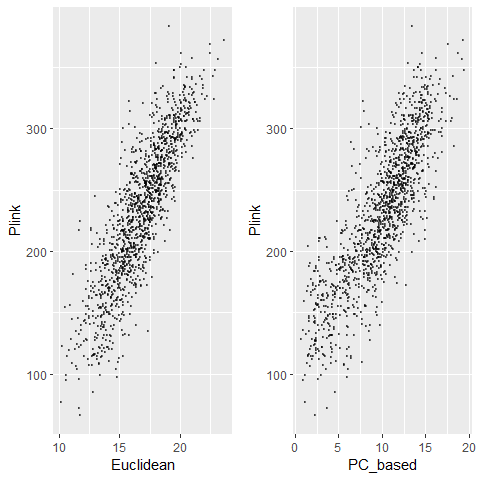

```r
# Plot some pairwise comparisons, providing names for the metrics
p_euc_plink <- gen_dist_corr(euc_dists, plink_dists, "Euclidean", "Plink")
p_pc_plink <- gen_dist_corr(pc_dists, plink_dists, "PC_based", "Plink")
# Show all plots as panels on a single plot
plot_grid(p_euc_plink, p_pc_plink, nrow = 1)
```

### Plot heatmap of one of the genetic distances with `gen_dist_hm()`

Let’s look at a heatmap of Euclidean distance for our example dataset.

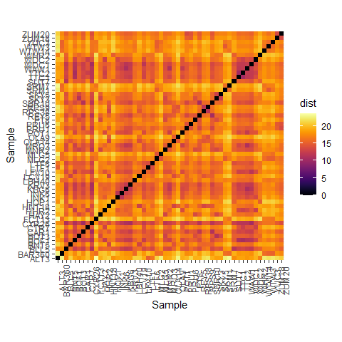

```r
gen_dist_hm(euc_dists)
```

For the proportions of shared alleles distance metric, keep in mind that the more similar two samples are, the *higher* the distance will be, so this metric’s heatmap will show the opposite trend as the other distance metrics available within `gen_dist()`:

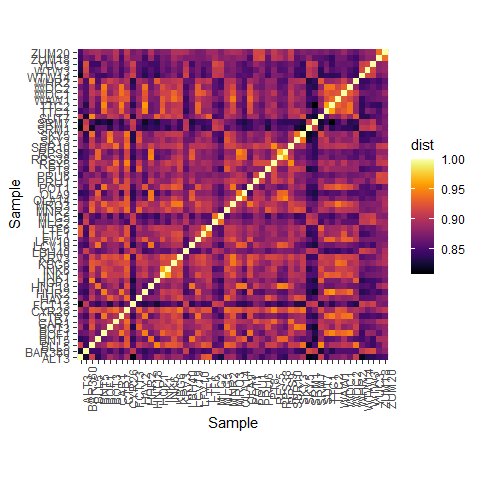

```r
dps_dists <- gen_dist(liz_vcf, dist_type = "dps")
gen_dist_hm(dps_dists)
```

## Additional documentation and citations

|  | Citation/URL | Details |
| --- | --- | --- |
| Associated code | [Goslee & Urban 2007](https://cran.r-project.org/web/packages/ecodist/index.html) | algatr’s calculation of Euclidean and Bray-Curtis distances using the `distance()` function within the ecodist package |
| Associated code | [Jombart 2008](https://academic.oup.com/bioinformatics/article/24/11/1403/191127); [Jombart & Ahmed 2011](https://academic.oup.com/bioinformatics/article/27/21/3070/218892) | algatr’s calculation of proportion of shared alleles using the `propShared()` function within the adegenet package |
| Associated literature | [Shirk et al., 2017](https://onlinelibrary.wiley.com/doi/abs/10.1111/1755-0998.12684) | Paper testing a number of different genetic distance metrics (including those used by algatr) for landscape genomics |